# PW3_LogisticRegression.R

#### 14 On the test set, predict the probability of purchasing the product by the users using the obtained model.

```r
pred_values <- predict(model2, newdata=test_set, type = 'response')
```

#### 15 Take a look on your predicted values for the variable Purchased. We predicted the probability that the user will purchase the product right? Now in order to compare your results with the real answers, transform the predicted values to 0 or 1 (1 if >0.5)

```r
pred_values <- ifelse(pred_values>0.5,1,0)
```

#### 16 Now in order to evaluate the model and its predictions, compute the confusion matrix. What do you obtain ?

```r
library(caret)
true_condition <- table(pred_values)
predict_condition <- table(test_set$Purchased)

#xtab<- table(predict_condition,true_condition)
#confusionMatrix(predict_condition, true_condition)


conf_mat = table(test_set$Purchased,pred_values > 0.5)

#     [,1] [,2]
#[1,]   57    7
#[2,]   10   26
```

#### 17 Calculate the accuracy, specificity, sensitivity and the precision of the model.

```r
accuracy <- (conf_mat[1]+conf_mat[4])/(sum(conf_mat))
#0.83

specificity <- (conf_mat[1])/(conf_mat[1] + conf_mat[3])
#0.890625

sensitivity <- (conf_mat[4])/(conf_mat[2] + conf_mat[4])
#0.722222

precision <- (conf_mat[1])/(conf_mat[1] + conf_mat[4])
#0.686747
```

```r
library(ROCR)
```

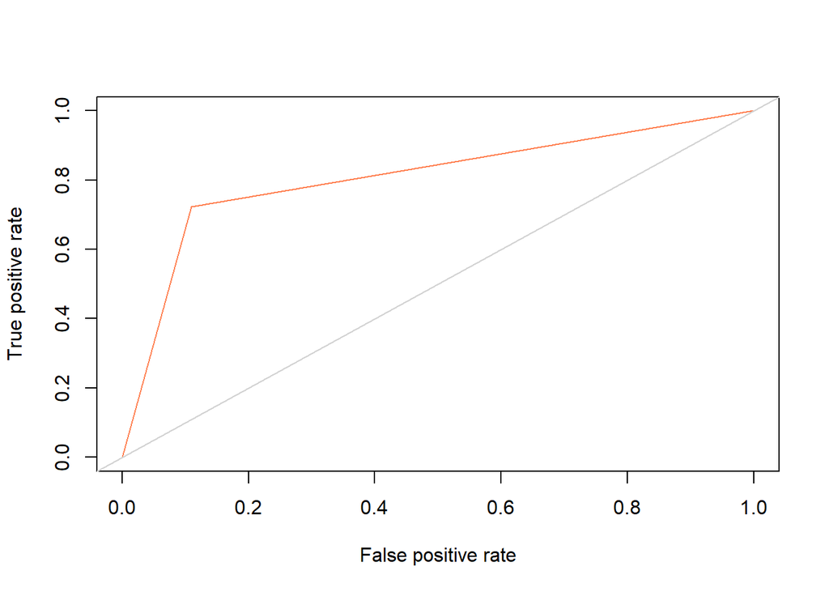

```r
pred_model2 = prediction(pred_values,test_set$Purchased)
AUC_2 = performance(pred_model2,"tpr","fpr")
plot(AUC_2,col="coral")
abline(0,1,col = "lightgrey")
```

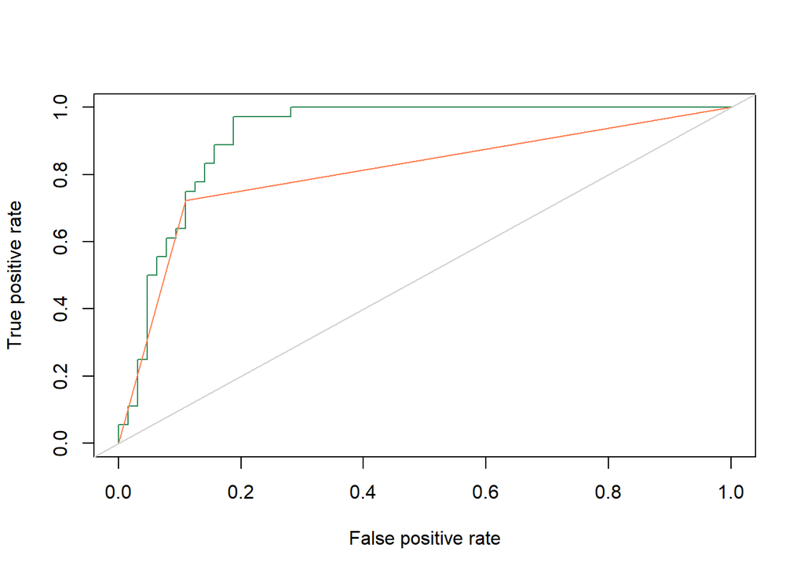

```r
predicted_values1 = predict(model2,newdata=test_set,type="response")
pred_model1 = prediction(predicted_values1,test_set$Purchased)
AUC_1 = performance(pred_model1,"tpr","fpr")
plot(AUC_1,col="seagreen")
lines(as.numeric(unlist( AUC_2@x.values )),
      as.numeric(unlist( AUC_2@y.values )),
      col="coral")
abline(0,1,col="lightgrey")
```